# L0. Introduction

# Noise in measurements

### Define all the imports

```python
import sys
import numpy as np
import pandas as pd
import matplotlib.pyplot as plt
import seaborn as sns

# Change to main folder for the imports
#sys.path.append('~/lib/probabilistic_robotics')
#sys.path.append('/home/ericguerrero/lib/probabilistic_robotics')

# Selecciono mi path (donde tengo colocado el repositorio del profe)
sys.path.append('/home/andreuet/lib/11765_MUSI')

# Ignore warning from pandas
pd.set_option('mode.chained_assignment',None)
```

### Importamos la clase Reader del directorio src del paquete data donde hay un módulo que se llama reader.py

```python
from src.data.reader import Reader
```

### Define new Functions

```python
# Crea un dataFrame llamado 'timeseries'
# 'data' es el array que cargará
# 'cols' es el nombre que tendrá cada columna del array

def build_timeseries(data,cols):
    timeseries = pd.DataFrame(data, columns=cols)
    timeseries['stamp'] = pd.to_datetime(timeseries['stamp'], unit='s')
    timeseries = timeseries.set_index('stamp')
    return timeseries
```

```python
# Cambia los códigos que tienen los landmarks y les pone su número
# Los landmarks empiezan su numeración a partir de 6 hasta 20
# Los robots su numeración es del 1 al 5

def filter_static_landmarks(lm, barcodes):
    for L,l in dict(barcodes).items(): # Translate barcode num to landmark num
        lm[lm==l]=L
    lm = lm[lm.type > 5] # Keep only static landmarks
    return lm
```

The previous block is for defining especific notebook function

### Load a dataset

En este laboratorio vamos a trabajar con:

# **`Dataset1`** y **`Robot5`**

```python
# Define dataset to read
dataset = "../data/MRCLAM_Dataset1" # Dataset
end_frame = 50000 # Extension of the dataset
robot = 'Robot5' # Robot

# Reader. Go to the src directory using VScode and inspect the class methods
self = Reader(dataset, robot, end_frame)
```

### Generate some representations

Dado un conjunto de Robots (5) y diferentes datasets. Elegimos un Robot y un DataSet durante un tiempo (end_frame).

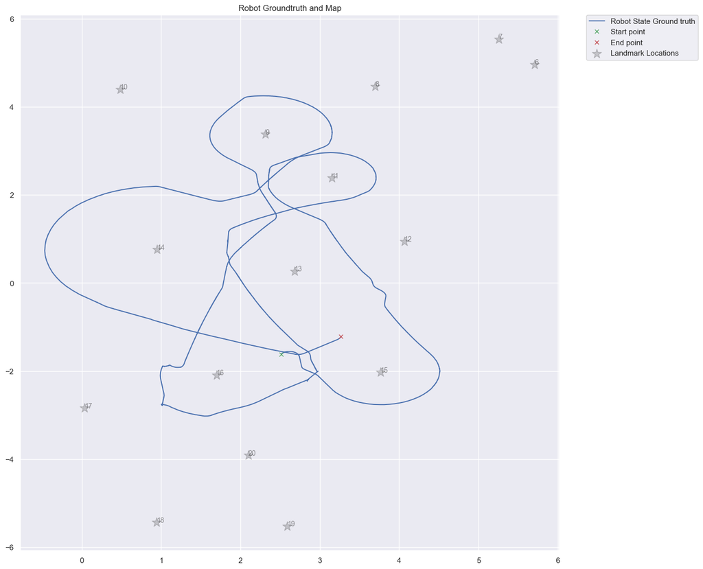

```python
# REPRESENT

#Definir estilo y tamaño del grid
sns.set(style="darkgrid")
plt.figure(figsize=(14, 14))

# Ground truth data
plt.plot(self.groundtruth_data[:, 1], self.groundtruth_data[:, 2], 'b', label="Robot State Ground truth")

# Start and end points
plt.plot(self.groundtruth_data[0, 1], self.groundtruth_data[0, 2], 'gx', label="Start point")
plt.plot(self.groundtruth_data[-1, 1], self.groundtruth_data[-1, 2], 'rx', label="End point")

# Landmark ground truth locations and indexes
landmark_xs = []
landmark_ys = []
for location in self.landmark_locations:
    landmark_xs.append(self.landmark_locations[location][0])
    landmark_ys.append(self.landmark_locations[location][1])
    index = self.landmark_indexes[location] + 5
    plt.text(landmark_xs[-1], landmark_ys[-1], str(index), alpha=0.5, fontsize=10)
plt.scatter(landmark_xs, landmark_ys, s=200, c='k', alpha=0.2, marker='*', label='Landmark Locations')

# plt.title("Localization with only odometry data")
plt.title("Robot Groundtruth and Map")
plt.legend(bbox_to_anchor=(1.05, 1), loc=2, borderaxespad=0.)
plt.show()
```

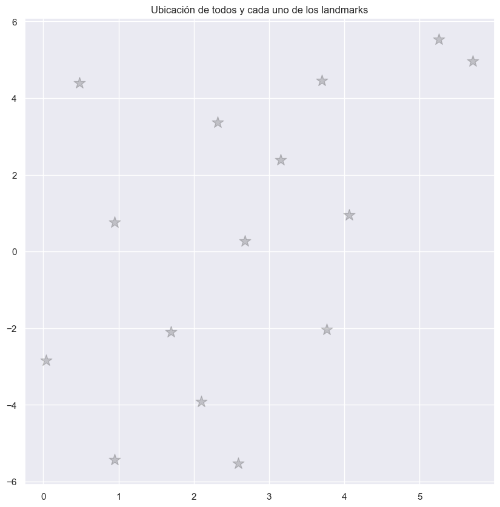

```python
# REPRESENT

#Definir estilo y tamaño del grid
sns.set(style="darkgrid")
plt.figure(figsize=(10, 10))

# ubicación de todos y cada uno de los landmarks
plt.scatter(landmark_xs, landmark_ys, s=200, c='k', alpha=0.2, marker='*', label='Landmark Locations')

plt.title("Ubicación de todos y cada uno de los landmarks")
plt.show()
```

Como los datos que lee Reader son arrays de numPy. Trataré sus datos como tal por lo que primero que debo determinar es el tamaño del array self.groundtruth_data.

```python
 self.groundtruth_data.shape
```

```
(41769, 4)
```

Tenemos 41769 filas y 4 columnas

El robot conoce el mapa. Sabemos donde están los LandMarks pero no sabe cual es cada uno de ellos.

- Robot State Ground Truth para analizar (benchmarking) necesitamos una trayectoria real que el robot ejecuta.
- Esta trayectoria es la trayectoria que el robot hizo. La representamos para saber como de bueno es el algoritmo que usamos.

### TASK EXAMPLE. Represent landmark measurements

#### Import data into pandas dataframes

Construimos una serie de dataframes

```python
# Build dataframes
groundtruth = build_timeseries(self.groundtruth_data, cols=['stamp','x','y','theta'])
measurements = build_timeseries(self.data, cols=['stamp','type','range_l','bearing_l'])
odometry = measurements[measurements.type == -1].rename(columns={'range_l': 'v', 'bearing_l': 'omega'})
landmarks = measurements[measurements.type != -1]
landmarks = filter_static_landmarks(landmarks, self.barcodes_data)
```

```python
landmarks.sum()
```

```
type         48902.000
range_l      12181.245
bearing_l       29.850
dtype: float64
```

```python
landmarks.describe(include='number')
```

|  | type | range_l | bearing_l |
| --- | --- | --- | --- |
| count | 3476.000000 | 3476.000000 | 3476.000000 |
| mean | 14.068470 | 3.504386 | 0.008587 |
| std | 3.757533 | 1.654531 | 0.297049 |
| min | 6.000000 | 0.921000 | -0.591000 |
| 25% | 11.000000 | 2.190750 | -0.211000 |
| 50% | 14.000000 | 3.183000 | 0.011000 |
| 75% | 17.000000 | 4.528250 | 0.268000 |
| max | 43.000000 | 9.250000 | 0.490000 |

```python
dict(self.barcodes_data).items()
```

```
dict_items([(1.0, 5.0), (2.0, 14.0), (3.0, 41.0), (4.0, 32.0), (5.0, 23.0), (6.0, 72.0), (7.0, 27.0), (8.0, 54.0), (9.0, 70.0), (10.0, 36.0), (11.0, 18.0), (12.0, 25.0), (13.0, 9.0), (14.0, 81.0), (15.0, 16.0), (16.0, 90.0), (17.0, 61.0), (18.0, 45.0), (19.0, 7.0), (20.0, 63.0)])
```

```python
groundtruth.head(50)
```

| stamp | x | y | theta |
| --- | --- | --- | --- |
| 2009-07-22 14:17:43.324999936 | 2.514231 | -1.614805 | 1.0114 |
| 2009-07-22 14:17:43.345999872 | 2.514209 | -1.614815 | 1.0114 |
| 2009-07-22 14:17:43.377000192 | 2.514235 | -1.614822 | 1.0111 |
| 2009-07-22 14:17:43.398999808 | 2.514260 | -1.614817 | 1.0112 |
| 2009-07-22 14:17:43.424000000 | 2.514285 | -1.614809 | 1.0114 |
| 2009-07-22 14:17:43.443000064 | 2.514267 | -1.614809 | 1.0114 |
| 2009-07-22 14:17:43.472000000 | 2.514200 | -1.614806 | 1.0113 |
| 2009-07-22 14:17:43.492999936 | 2.514197 | -1.614804 | 1.0113 |
| 2009-07-22 14:17:43.523000064 | 2.514290 | -1.614782 | 1.0113 |
| 2009-07-22 14:17:43.543000064 | 2.514302 | -1.614775 | 1.0114 |
| 2009-07-22 14:17:43.580000000 | 2.514258 | -1.614804 | 1.0114 |
| 2009-07-22 14:17:43.583000064 | 2.514229 | -1.614818 | 1.0113 |
| 2009-07-22 14:17:43.620999936 | 2.514192 | -1.614833 | 1.0112 |
| 2009-07-22 14:17:43.622999808 | 2.514207 | -1.614826 | 1.0113 |
| 2009-07-22 14:17:43.668000000 | 2.514267 | -1.614810 | 1.0112 |
| 2009-07-22 14:17:43.688999936 | 2.514262 | -1.614804 | 1.0112 |
| 2009-07-22 14:17:43.716999936 | 2.514214 | -1.614814 | 1.0112 |
| 2009-07-22 14:17:43.736999936 | 2.514196 | -1.614821 | 1.0112 |
| 2009-07-22 14:17:43.768000000 | 2.514225 | -1.614823 | 1.0114 |
| 2009-07-22 14:17:43.789999872 | 2.514249 | -1.614816 | 1.0115 |
| 2009-07-22 14:17:43.815000064 | 2.514263 | -1.614795 | 1.0113 |
| 2009-07-22 14:17:43.840000000 | 2.514239 | -1.614793 | 1.0112 |
| 2009-07-22 14:17:43.868000000 | 2.514171 | -1.614795 | 1.0111 |
| 2009-07-22 14:17:43.888000000 | 2.514192 | -1.614795 | 1.0111 |
| 2009-07-22 14:17:43.921999872 | 2.514276 | -1.614798 | 1.0114 |
| 2009-07-22 14:17:43.969000192 | 2.514205 | -1.614828 | 1.0113 |
| 2009-07-22 14:17:43.990000128 | 2.514194 | -1.614820 | 1.0113 |
| 2009-07-22 14:17:44.016000000 | 2.514249 | -1.614793 | 1.0112 |
| 2009-07-22 14:17:44.036999936 | 2.514266 | -1.614785 | 1.0112 |
| 2009-07-22 14:17:44.068000000 | 2.514250 | -1.614795 | 1.0114 |
| 2009-07-22 14:17:44.089999872 | 2.514232 | -1.614804 | 1.0114 |
| 2009-07-22 14:17:44.117000192 | 2.514196 | -1.614813 | 1.0112 |
| 2009-07-22 14:17:44.137000192 | 2.514206 | -1.614812 | 1.0112 |
| 2009-07-22 14:17:44.168999936 | 2.514272 | -1.614794 | 1.0113 |
| 2009-07-22 14:17:44.192000000 | 2.514279 | -1.614792 | 1.0114 |
| 2009-07-22 14:17:44.214999808 | 2.514269 | -1.614805 | 1.0114 |
| 2009-07-22 14:17:44.236000000 | 2.514250 | -1.614804 | 1.0114 |
| 2009-07-22 14:17:44.266000128 | 2.514199 | -1.614802 | 1.0113 |
| 2009-07-22 14:17:44.288000000 | 2.514209 | -1.614799 | 1.0113 |
| 2009-07-22 14:17:44.319000064 | 2.514313 | -1.614815 | 1.0113 |
| 2009-07-22 14:17:44.340000000 | 2.514317 | -1.614812 | 1.0114 |
| 2009-07-22 14:17:44.368999936 | 2.514197 | -1.614806 | 1.0113 |
| 2009-07-22 14:17:44.390000128 | 2.514175 | -1.614810 | 1.0113 |
| 2009-07-22 14:17:44.416000000 | 2.514251 | -1.614815 | 1.0113 |
| 2009-07-22 14:17:44.436000000 | 2.514291 | -1.614811 | 1.0113 |
| 2009-07-22 14:17:44.467000064 | 2.514277 | -1.614817 | 1.0114 |
| 2009-07-22 14:17:44.488000000 | 2.514257 | -1.614818 | 1.0114 |
| 2009-07-22 14:17:44.519000064 | 2.514207 | -1.614809 | 1.0113 |
| 2009-07-22 14:17:44.540000000 | 2.514222 | -1.614808 | 1.0113 |
| 2009-07-22 14:17:44.566999808 | 2.514263 | -1.614806 | 1.0114 |

```python
measurements.head()
```

| stamp | type | range_l | bearing_l |
| --- | --- | --- | --- |
| 2009-07-22 14:17:54.237999872 | -1.0 | 0.086 | -0.398 |
| 2009-07-22 14:17:54.268999936 | -1.0 | 0.086 | -0.398 |
| 2009-07-22 14:17:54.288999936 | -1.0 | 0.086 | -0.398 |
| 2009-07-22 14:17:54.349999872 | -1.0 | 0.086 | -0.398 |
| 2009-07-22 14:17:54.371000064 | -1.0 | 0.086 | -0.398 |

```python
odometry.head()
```

| stamp | type | v | omega |
| --- | --- | --- | --- |
| 2009-07-22 14:17:54.237999872 | -1.0 | 0.086 | -0.398 |
| 2009-07-22 14:17:54.268999936 | -1.0 | 0.086 | -0.398 |
| 2009-07-22 14:17:54.288999936 | -1.0 | 0.086 | -0.398 |
| 2009-07-22 14:17:54.349999872 | -1.0 | 0.086 | -0.398 |
| 2009-07-22 14:17:54.371000064 | -1.0 | 0.086 | -0.398 |

```python
groundtruth.info()
```

```
<class 'pandas.core.frame.DataFrame'>
DatetimeIndex: 41769 entries, 2009-07-22 14:17:43.324999936 to 2009-07-22 14:29:32.430000128
Data columns (total 3 columns):
 #   Column  Non-Null Count  Dtype
---  ------  --------------  -----
 0   x       41769 non-null  float64
 1   y       41769 non-null  float64
 2   theta   41769 non-null  float64
dtypes: float64(3)
memory usage: 1.3 MB
```

```python
landmarks.head()
```

| stamp | type | range_l | bearing_l |
| --- | --- | --- | --- |
| 2009-07-22 14:17:56.451000064 | 12.0 | 2.681 | 0.467 |
| 2009-07-22 14:17:56.680999936 | 15.0 | 1.170 | -0.577 |
| 2009-07-22 14:17:56.918999808 | 15.0 | 1.224 | -0.483 |
| 2009-07-22 14:17:57.155000064 | 15.0 | 1.253 | -0.407 |
| 2009-07-22 14:17:57.394000128 | 15.0 | 1.281 | -0.325 |

```python
landmarks.info()
```

```
<class 'pandas.core.frame.DataFrame'>
DatetimeIndex: 3476 entries, 2009-07-22 14:17:56.451000064 to 2009-07-22 14:29:32.299000064
Data columns (total 3 columns):
 #   Column     Non-Null Count  Dtype
---  ------     --------------  -----
 0   type       3476 non-null   float64
 1   range_l    3476 non-null   float64
 2   bearing_l  3476 non-null   float64
dtypes: float64(3)
memory usage: 108.6 KB
```

```python
groundtruth.shape
```

```
(41769, 3)
```

#### Transform landmark measurements to global coordinates

Join dataframes (link observations to particular GT locations)

```python
data = landmarks.join(groundtruth).dropna()
data.head(15)
```

| stamp | type | range_l | bearing_l | x | y | theta |
| --- | --- | --- | --- | --- | --- | --- |
| 2009-07-22 14:18:49.991000064 | 17.0 | 4.594 | 0.164 | 4.513066 | -1.987889 | 1.7156 |
| 2009-07-22 14:18:49.991000064 | 13.0 | 5.585 | 0.256 | 4.513066 | -1.987889 | 1.7156 |
| 2009-07-22 14:18:55.882999808 | 10.0 | 7.136 | 0.044 | 4.402364 | -1.626464 | 2.1074 |
| 2009-07-22 14:18:55.882999808 | 13.0 | 2.610 | 0.204 | 4.402364 | -1.626464 | 2.1074 |
| 2009-07-22 14:18:56.120000000 | 13.0 | 5.439 | -0.159 | 4.393292 | -1.611678 | 2.1307 |
| 2009-07-22 14:18:56.355000064 | 13.0 | 2.588 | 0.171 | 4.384774 | -1.598271 | 2.1421 |
| 2009-07-22 14:18:58.991000064 | 13.0 | 2.400 | 0.176 | 4.284519 | -1.437405 | 2.1464 |
| 2009-07-22 14:19:00.397000192 | 13.0 | 2.275 | 0.215 | 4.231577 | -1.352456 | 2.1121 |
| 2009-07-22 14:19:00.397000192 | 17.0 | 3.866 | -0.269 | 4.231577 | -1.352456 | 2.1121 |
| 2009-07-22 14:19:03.698999808 | 10.0 | 6.774 | 0.069 | 4.113025 | -1.143571 | 2.0779 |
| 2009-07-22 14:19:04.172000000 | 17.0 | 3.657 | -0.255 | 4.096943 | -1.113351 | 2.0857 |
| 2009-07-22 14:19:05.356000000 | 17.0 | 3.577 | -0.245 | 4.056629 | -1.038995 | 2.0717 |
| 2009-07-22 14:19:05.356000000 | 13.0 | 4.827 | -0.128 | 4.056629 | -1.038995 | 2.0717 |
| 2009-07-22 14:19:05.356000000 | 10.0 | 6.480 | 0.079 | 4.056629 | -1.038995 | 2.0717 |
| 2009-07-22 14:19:05.356000000 | 12.0 | 1.867 | -0.500 | 4.056629 | -1.038995 | 2.0717 |

```python
data.shape
```

```
(221, 6)
```

Transform distance and bearing to global coordinates

```python
range_l = data.range_l
bearing_l = data.bearing_l
x_t = data.x
y_t =  data.y
theta_t = data.theta

x = range_l*np.cos(bearing_l)
y = range_l*np.sin(bearing_l)

data['x_l'] = x_t + x*np.cos(theta_t) - y*np.sin(theta_t)
data['y_l'] = y_t + x*np.sin(theta_t) + y*np.cos(theta_t)
data.head()
```

| stamp | type | range_l | bearing_l | x | y | theta | x_l | y_l |
| --- | --- | --- | --- | --- | --- | --- | --- | --- |
| 2009-07-22 14:18:49.991000064 | 17.0 | 4.594 | 0.164 | 4.513066 | -1.987889 | 1.7156 | 3.116861 | 2.388805 |
| 2009-07-22 14:18:49.991000064 | 13.0 | 5.585 | 0.256 | 4.513066 | -1.987889 | 1.7156 | 2.334031 | 3.154487 |
| 2009-07-22 14:18:55.882999808 | 10.0 | 7.136 | 0.044 | 4.402364 | -1.626464 | 2.1074 | 0.488063 | 4.340172 |
| 2009-07-22 14:18:55.882999808 | 13.0 | 2.610 | 0.204 | 4.402364 | -1.626464 | 2.1074 | 2.641309 | 0.299877 |
| 2009-07-22 14:18:56.120000000 | 13.0 | 5.439 | -0.159 | 4.393292 | -1.611678 | 2.1307 | 2.270720 | 3.396057 |

#### Represent measurements on top of our known map

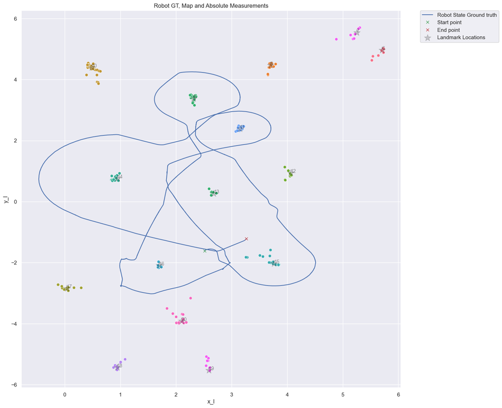

```python
# REPRESENT

#Definir estilo y tamaño del grid
sns.set(style="darkgrid")
plt.figure(figsize=(14, 14))

# Measurements (New added function)
#num_landmarks = len(landmarks.type.unique())
# La línea anterior me daba un warning porque no coincidían lo colores y los landmarks
# la siguiente línea corrige el fallo ajustando exactamente el número
# correcto de colores basados en la cantidad de tipos de landmarks en tus datos.
num_landmarks = len(data['type'].unique())
sns.scatterplot(data,x="x_l",y="y_l", hue="type", palette=sns.color_palette("husl", num_landmarks),legend=False)

# Ground truth data
plt.plot(self.groundtruth_data[:, 1], self.groundtruth_data[:, 2], 'b', label="Robot State Ground truth")

# Start and end points
plt.plot(self.groundtruth_data[0, 1], self.groundtruth_data[0, 2], 'gx', label="Start point")
plt.plot(self.groundtruth_data[-1, 1], self.groundtruth_data[-1, 2], 'rx', label="End point")

# Landmark ground truth locations and indexes
landmark_xs = []
landmark_ys = []
for location in self.landmark_locations:
    landmark_xs.append(self.landmark_locations[location][0])
    landmark_ys.append(self.landmark_locations[location][1])
    index = self.landmark_indexes[location] + 5
    plt.text(landmark_xs[-1], landmark_ys[-1], str(index), alpha=0.5, fontsize=10)
plt.scatter(landmark_xs, landmark_ys, s=200, c='k', alpha=0.2, marker='*', label='Landmark Locations')

#plt.title("Localization with only odometry data")
plt.title("Robot GT, Map and Absolute Measurements")
plt.legend(bbox_to_anchor=(1.05, 1), loc=2, borderaxespad=0.)
plt.show()
```

```python
self.groundtruth_data
```

```
array([[ 1.24827226e+09,  2.51423090e+00, -1.61480470e+00,
         1.01140000e+00],
       [ 1.24827226e+09,  2.51420890e+00, -1.61481500e+00,
         1.01140000e+00],
       [ 1.24827226e+09,  2.51423450e+00, -1.61482200e+00,
         1.01110000e+00],
       ...,
       [ 1.24827297e+09,  3.26632800e+00, -1.21487470e+00,
         1.42100000e+00],
       [ 1.24827297e+09,  3.26642930e+00, -1.21432030e+00,
         1.42510000e+00],
       [ 1.24827297e+09,  3.26649770e+00, -1.21240560e+00,
         1.43810000e+00]])
```

```python
print(self.groundtruth_data[0])
```

```
[ 1.24827226e+09  2.51423090e+00 -1.61480470e+00  1.01140000e+00]
```

```python
print(self.groundtruth_data[1])
```

```
[ 1.24827226e+09  2.51420890e+00 -1.61481500e+00  1.01140000e+00]
```

```python
np.sqrt(np.square(self.groundtruth_data[2,1]-self.groundtruth_data[1,1])+np.square(self.groundtruth_data[2,2]-self.groundtruth_data[1,2]))
```

```
2.6539781461349997e-05
```

## TASK 1. Get dataset specifications

#### Get path length

Sum displacements from the GT

### Por coordenadas

```python
# la representación de dos puntos en un plano cartesiano lo definimos como
# p0=(x,y)
# p1=(m,n)
# distanciaEuclidiana = sqrt( (m-x)*2 + (n-y)*2 )

# distancia euclidiana (de)
de = 0
# distancia total (dt): el acumulado de todas las 'de'
dt=0
# copio el array de groundtruth
g=np.copy(self.groundtruth_data)

# inicializo el primer valor
x=g[0,1]
y=g[0,2]

filas, columnas = g.shape
for fila in range(filas-1):
    m = g[fila+1,1]
    n = g[fila+1,2]

    de = np.sqrt(np.square(m-x)+np.square(n-y))
    #print(de, end=' ')
    # actualizo el siguiente valor
    x = m
    y = n
    dt = dt + de

print("distancia total", dt)
```

```
distancia total 40.05441504222708
```

```python
type(dt)
```

```
numpy.float64
```

### Como si fuese un punto

```python
# Punto inicial p0(x,y)
# Punto final   p1(m,n)

# distancia euclidiana (de)
de = 0
# distancia total (dt)
dt=0
# copio el array de groundtruth
g=np.copy(self.groundtruth_data)

# inicializo el primer valor
p0 = np.array ((g[0,1],g[0,2]))

filas, columnas = g.shape
for fila in range(filas-1):
    p1 = np.array ((g[fila+1,1],g[fila+1,2]))
    # Con norm(p0-p1) calculamos la norma
    de = np.linalg.norm(p0-p1)
    # También lo podríamos hacer haciendo un producto escalar dot()
    # de = np.sqrt(np.dot(p0, p1))
    #print(de, end=' ')
    # actualizo el siguiente valor
    p0 = p1
    dt = dt + de

print("distancia total", dt)
```

```
distancia total 40.05441504222708
```

```python
type(dt)
```

```
numpy.float64
```

### Otra manera de hacerlo es con scipy y su distancia euclidiana

En este caso y para que sea de otra manera el array lo reduciré hasta mis necesidades, dejándolo únicamente en dos columnas, la de x & la de y.

```python
from scipy.spatial import distance

# copio el array de groundtruth
g=np.copy(self.groundtruth_data)

#columna 0 y columna 3 que queremos eliminar
g2 = np.delete(g, (0,3), axis=1)

# inicializo los valores necesarios
p0 = np.array ((g2[0,0],g2[0,1]))
de = 0
dt = 0


filas, columnas = g2.shape
for fila in range(filas-1):
    p1 = np.array ((g2[fila+1,0],g2[fila+1,1]))
    # Con norm(p0-p1) calculamos la norma
    de = distance.euclidean(p0, p1)
    # actualizo el siguiente valor
    p0 = p1
    dt = dt + de


print("distancia total", dt)
```

```
distancia total 40.05441504222708
```

#### Get duration

```python
# En la primera columna (0), se encuentra el timestamp en formato Epoch
# como está ordenado por lo que he visto, cojo la última y le resto la primera
# El resultado lo convierto a formato datetime y lo represento

import datetime as day


duracionEpoch = self.groundtruth_data[-1,0]-self.groundtruth_data[0,0]
print("duración Epoch", duracionEpoch)
print("duración hh:mm:ss", day.datetime.utcfromtimestamp(duracionEpoch).strftime('%H:%M:%S'))
```

```
duración Epoch 709.1050000190735
duración hh:mm:ss 00:11:49
```

```python
print(type(duracionEpoch))
```

```
<class 'numpy.float64'>
```

#### Get number of landmark measurements

Son los landmarks que se ven (corrección).

Si se viesen mas, la trayectoria sería más precisa.

En 'TASK EXAMPLE. Represent landmark measurements' se crean una serie de dataFrames. Uno de ellos es `landmarks`, .se guardan todas las medidas que realiza el robot. De ahí se separan, las que son odometrías van al dataFrame `odometry`, las que no, se guardan en `landmarks`. En `landmarks`tenemos medidas de los **Robots** y **landmarks** que 've'. Posteriormente, y mediante la función `filter_static_landmarks(lm, barcodes)` nos quedamos únicamente con los que son *estáticos*, es decir, los que *no son robots*. así la longitud de `landmarks` (número de filas), contiene la respuesta a esta cuestión.

```python
num_landmark = len(landmarks)
print("número de medidas de landmarks:",num_landmark)
```

```
número de medidas de landmarks: 3476
```

```python
landmarks
```

| stamp | type | range_l | bearing_l |
| --- | --- | --- | --- |
| 2009-07-22 14:17:56.451000064 | 12.0 | 2.681 | 0.467 |
| 2009-07-22 14:17:56.680999936 | 15.0 | 1.170 | -0.577 |
| 2009-07-22 14:17:56.918999808 | 15.0 | 1.224 | -0.483 |
| 2009-07-22 14:17:57.155000064 | 15.0 | 1.253 | -0.407 |
| 2009-07-22 14:17:57.394000128 | 15.0 | 1.281 | -0.325 |
| ... | ... | ... | ... |
| 2009-07-22 14:29:31.320000000 | 12.0 | 2.374 | 0.206 |
| 2009-07-22 14:29:31.559000064 | 12.0 | 2.399 | 0.126 |
| 2009-07-22 14:29:31.815000064 | 12.0 | 2.420 | 0.054 |
| 2009-07-22 14:29:32.064000000 | 12.0 | 2.423 | -0.066 |
| 2009-07-22 14:29:32.299000064 | 13.0 | 4.383 | 0.407 |

3476 rows × 3 columns

#### Get distance between initial and end positions

```python
# distancia euclidiana (de)
de = 0

# copio el array de groundtruth
g=np.copy(self.groundtruth_data)

# Punto inicial p0(x,y)
p0 = np.array ((g[0,1],g[0,2]))

# Punto final   p1(m,n)
p1 = np.array ((g[-1,1],g[-1,2]))

# Con norm(p0-p1) calculamos la norma
de = np.linalg.norm(p0-p1)

print("Posición inicial:", p0)
print("Posición final:", p1)
print("Distancia entre posición incial y final:", de)
```

```
Posición inicial: [ 2.5142309 -1.6148047]
Posición final: [ 3.2664977 -1.2124056]
Distancia entre posición incial y final: 0.8531297521848891
```

#### Measurements density

Mean number of measures per unit of distance

```python
type(landmarks.shape[0])
```

```
int
```

```python
type(dt)
```

```
float
```

```python
density = landmarks.shape[0] / dt

print("(Número de medidas de landmarks) / (Longitud del camino) = :", density, "'m**-1'")
```

```
(Número de medidas de landmarks) / (Longitud del camino) = : 86.7819439214242 'm**-1'
```

### TASK 2. Iterate over diferent datasets

#### Generate metrics

```python
'''
Cálculo de la longitud total 'real' del recorrido realizado por el robot
'''
def calcula_length(data):
    try:
        # Punto inicial p0(x,y)
        # Punto final   p1(m,n)
        # distancia euclidiana (de)
        de = 0
        # distancia total (dt)
        length=0
        # inicializo el primer valor
        p0 = np.array ((data[0,1],data[0,2]))

        filas, columnas = data.shape
        for fila in range(filas-1):
            p1 = np.array ((data[fila+1,1],data[fila+1,2]))
            # Con norm(p0-p1) calculamos la norma
            de = np.linalg.norm(p0-p1)
            # actualizo el siguiente valor
            p0 = p1
            length = length + de
        return length
    except Exception as e:
        print(f"Error al calcular: {str(e)}")
        return None

'''
Esta función es como matar moscas a cañonazos por que la mitad de las cosas
no nos hacen falta pero como en el ejemplo ya estaba definido, pues lo uso.
De hecho, no paso ningún parámetro (todo está como global).
Por simplicidad a la hora de hacer esta primera práctica lo he elegido así.

Uso la función 'build_timeseries()' para obtener el dataframe 'measurements'.
De este dataframe me quedo con los que su tipo es '-1'.
Uso la función 'filter_static_landmarks()' para quedarme sólo con los
landmarks y quitar todos los robots que veía en las medidas.

El número de filas resultante son los landmarks que he visto.
'''
def calcula_numero_landmarks():
    try:
        # Build dataframes
        measurements = build_timeseries(self.data,
                                        cols=['stamp',
                                              'type',
                                              'range_l',
                                              'bearing_l'])
        landmarks = measurements[measurements.type != -1]
        landmarks = filter_static_landmarks(landmarks, self.barcodes_data)

        return len(landmarks)
    except Exception as e:
        print(f"Error al calcular: {str(e)}")
        return None

'''
Cálculo de la distancia entre el punto inicial y el punto final
'''
def calcula_distancia(data):
    try:
        # Punto inicial p0(x,y)
        p0 = np.array ((data[0,1],data[0,2]))
        # Punto final   p1(m,n)
        p1 = np.array ((data[-1,1],data[-1,2]))

        return np.linalg.norm(p0-p1)
    except Exception as e:
        print(f"Error al calcular: {str(e)}")
        return None


'''

 Código principal

 Aquí iteraremos sobre 8 DataSets y sobre los 5 robots.
 Obtendremos (más o menos) las métricas que hemos calculado antes.
 Por último lo guardaremos todo en un dataFrame 'metrics' para su posterior
 consulta.

'''
datasets = ["../data/MRCLAM_Dataset1",
            "../data/MRCLAM_Dataset2",
            "../data/MRCLAM_Dataset3",
            "../data/MRCLAM_Dataset4",
            "../data/MRCLAM_Dataset5",
            "../data/MRCLAM_Dataset6",
            "../data/MRCLAM_Dataset7",
            "../data/MRCLAM_Dataset8"]
robots = ['Robot1',
          'Robot2',
          'Robot3',
          'Robot4',
          'Robot5']

metrics = pd.DataFrame(columns=['dataset',
                                'robot',
                                'length',
                                'duration',
                                'n_landmarks',
                                'distance',
                                'm_density'])

# Vaciamos "por si acaso" el dataFrame metrics pero manteniendo las columnas
# metrics = pd.DataFrame(columns=metrics.columns)
end_frame = 50000 # Extension of the dataset


for ds in datasets:
    for rob in robots:
        # Vamos cargando los dataSets haciéndonos valer de la clase creada
        # al inicio del notebook
        # Define dataset to read
        dataset = ds # Dataset
        robot = rob # Robot
        # Reader
        self = Reader(dataset, robot, end_frame)


        # length = es la longitud total del recorrido real
        # realizado por el robot y que guarda esa información en el
        # numPy array 'groundtruth_data'
        length = calcula_length(self.groundtruth_data)
        # duration = la diferencia entre el inicio y final
        # de la toma de medidas
        # Las unidades son Epoch (Unix Time)
        duration = self.groundtruth_data[-1,0]-self.groundtruth_data[0,0]
        #n_landmarks = calculate_n_landmarks(data)
        n_landmarks = calcula_numero_landmarks()
        #distance = calculate_distance(data)
        distance = calcula_distancia(self.groundtruth_data)
        #m_density = calculate_m_density(data)
        m_density = n_landmarks / length


        # Añadimos un nuevo elemento al dataFrame metrics
        # al haber quedado obsoleto el método 'append' debo
        # crear una nueva fila y emplear el método 'concat' en su lugar.
        nueva_fila = {'dataset': ds,
           'robot': rob,
           'length': length,
           'duration': duration,
           'n_landmarks': n_landmarks,
           'distance': distance,
           'm_density': m_density}

        metrics = pd.concat([metrics, pd.DataFrame([nueva_fila])],
                            ignore_index=True)


# After the loops, you'll have the 'metrics' dataframe containing all the data
```

```python
len(nueva_fila)
```

```
7
```

```python
type(nueva_fila) is dict
```

```
True
```

```python
# Vemos si 'datasets' y 'robots' son de tipo listas
# También lo podemos hacer con el método type(datasets)

isinstance(datasets, list) and isinstance(robots, list)
```

```
True
```

```python
metrics.info()
```

```
<class 'pandas.core.frame.DataFrame'>
RangeIndex: 40 entries, 0 to 39
Data columns (total 7 columns):
 #   Column       Non-Null Count  Dtype
---  ------       --------------  -----
 0   dataset      40 non-null     object
 1   robot        40 non-null     object
 2   length       40 non-null     float64
 3   duration     40 non-null     float64
 4   n_landmarks  40 non-null     object
 5   distance     40 non-null     float64
 6   m_density    40 non-null     float64
dtypes: float64(4), object(3)
memory usage: 2.3+ KB
```

```python
metrics
```

|  | dataset | robot | length | duration | n_landmarks | distance | m_density |
| --- | --- | --- | --- | --- | --- | --- | --- |
| 0 | ../data/MRCLAM_Dataset1 | Robot1 | 44.471897 | 732.992 | 2252 | 5.445376 | 50.638722 |
| 1 | ../data/MRCLAM_Dataset1 | Robot2 | 41.001583 | 718.729 | 2538 | 4.122505 | 61.900049 |
| 2 | ../data/MRCLAM_Dataset1 | Robot3 | 40.472516 | 701.179 | 2837 | 1.938364 | 70.096952 |
| 3 | ../data/MRCLAM_Dataset1 | Robot4 | 40.266531 | 749.249 | 1511 | 0.520626 | 37.524961 |
| 4 | ../data/MRCLAM_Dataset1 | Robot5 | 40.054415 | 709.105 | 3476 | 0.853130 | 86.781944 |
| 5 | ../data/MRCLAM_Dataset2 | Robot1 | 44.132536 | 736.912 | 2411 | 3.622068 | 54.630897 |
| 6 | ../data/MRCLAM_Dataset2 | Robot2 | 42.277640 | 745.616 | 2391 | 6.786612 | 56.554718 |
| 7 | ../data/MRCLAM_Dataset2 | Robot3 | 42.452768 | 716.869 | 3259 | 2.060985 | 76.767668 |
| 8 | ../data/MRCLAM_Dataset2 | Robot4 | 40.687899 | 883.038 | 2001 | 3.156675 | 49.179242 |
| 9 | ../data/MRCLAM_Dataset2 | Robot5 | 37.888899 | 709.105 | 4518 | 3.922297 | 119.243369 |
| 10 | ../data/MRCLAM_Dataset3 | Robot1 | 38.115290 | 729.779 | 2740 | 5.905363 | 71.887162 |
| 11 | ../data/MRCLAM_Dataset3 | Robot2 | 37.895789 | 732.447 | 2749 | 4.430365 | 72.541041 |
| 12 | ../data/MRCLAM_Dataset3 | Robot3 | 32.019980 | 723.119 | 3283 | 1.313949 | 102.529733 |
| 13 | ../data/MRCLAM_Dataset3 | Robot4 | 22.244821 | 655.834 | 2229 | 1.719449 | 100.203097 |
| 14 | ../data/MRCLAM_Dataset3 | Robot5 | 34.825493 | 709.996 | 4420 | 1.466074 | 126.918519 |
| 15 | ../data/MRCLAM_Dataset4 | Robot1 | 37.246809 | 695.244 | 3096 | 3.082593 | 83.121215 |
| 16 | ../data/MRCLAM_Dataset4 | Robot2 | 37.555689 | 746.954 | 2909 | 3.850953 | 77.458305 |
| 17 | ../data/MRCLAM_Dataset4 | Robot3 | 38.312659 | 697.502 | 3290 | 0.513213 | 85.872400 |
| 18 | ../data/MRCLAM_Dataset4 | Robot4 | 37.528289 | 744.133 | 2447 | 3.905909 | 65.204145 |
| 19 | ../data/MRCLAM_Dataset4 | Robot5 | 29.371885 | 707.035 | 5251 | 3.057923 | 178.776405 |
| 20 | ../data/MRCLAM_Dataset5 | Robot1 | 40.943548 | 649.496 | 1758 | 1.420398 | 42.937168 |
| 21 | ../data/MRCLAM_Dataset5 | Robot2 | 41.657608 | 684.596 | 1686 | 2.557015 | 40.472799 |
| 22 | ../data/MRCLAM_Dataset5 | Robot3 | 40.436074 | 665.625 | 2967 | 0.833394 | 73.375077 |
| 23 | ../data/MRCLAM_Dataset5 | Robot4 | 31.494474 | 664.610 | 1796 | 4.352351 | 57.025876 |
| 24 | ../data/MRCLAM_Dataset5 | Robot5 | 39.719374 | 660.794 | 2314 | 3.201100 | 58.258723 |
| 25 | ../data/MRCLAM_Dataset6 | Robot1 | 48.721800 | 753.463 | 1535 | 6.925408 | 31.505404 |
| 26 | ../data/MRCLAM_Dataset6 | Robot2 | 40.731744 | 665.735 | 2063 | 0.841034 | 50.648458 |
| 27 | ../data/MRCLAM_Dataset6 | Robot3 | 40.686598 | 665.051 | 3228 | 3.257578 | 79.338165 |
| 28 | ../data/MRCLAM_Dataset6 | Robot4 | 38.857108 | 829.267 | 1582 | 2.566482 | 40.713272 |
| 29 | ../data/MRCLAM_Dataset6 | Robot5 | 37.819791 | 677.723 | 3239 | 2.546177 | 85.642989 |
| 30 | ../data/MRCLAM_Dataset7 | Robot1 | 42.332078 | 721.887 | 1926 | 4.927688 | 45.497412 |
| 31 | ../data/MRCLAM_Dataset7 | Robot2 | 42.360545 | 709.270 | 2733 | 2.890365 | 64.517584 |
| 32 | ../data/MRCLAM_Dataset7 | Robot3 | 40.111503 | 755.056 | 3887 | 0.861792 | 96.904869 |
| 33 | ../data/MRCLAM_Dataset7 | Robot4 | 27.405036 | 662.795 | 1264 | 0.964642 | 46.122910 |
| 34 | ../data/MRCLAM_Dataset7 | Robot5 | 33.924306 | 702.881 | 2731 | 2.491747 | 80.502753 |
| 35 | ../data/MRCLAM_Dataset8 | Robot1 | 40.960108 | 719.788 | 2016 | 2.458007 | 49.218620 |
| 36 | ../data/MRCLAM_Dataset8 | Robot2 | 40.777738 | 676.208 | 2909 | 3.240859 | 71.337944 |
| 37 | ../data/MRCLAM_Dataset8 | Robot3 | 38.156232 | 734.392 | 3192 | 1.052341 | 83.656059 |
| 38 | ../data/MRCLAM_Dataset8 | Robot4 | 35.442117 | 778.136 | 1811 | 3.240746 | 51.097399 |
| 39 | ../data/MRCLAM_Dataset8 | Robot5 | 37.008745 | 677.750 | 3952 | 4.570930 | 106.785573 |

#### Represent metrics

Use seaborn library (catplot)

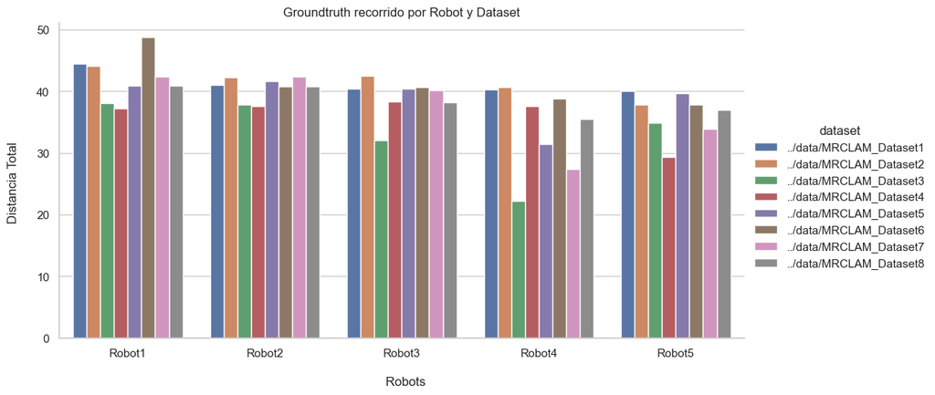

```python
# Representar la longitud de camino recorrido
import seaborn as sns
import matplotlib.pyplot as plt

# Configurar el estilo de Seaborn
sns.set(style="whitegrid")

# Crear un gráfico de barras para la longitud promedio
g = sns.catplot(data=metrics, x='robot', y='length', hue='dataset', kind='bar' ,  aspect=2)


# Configurar el título y etiquetas de los ejes
plt.title("Groundtruth recorrido por Robot y Dataset")
plt.xlabel("\n  Robots")
plt.ylabel("Distancia Total \n")

# Mostrar el gráfico
plt.show()
```

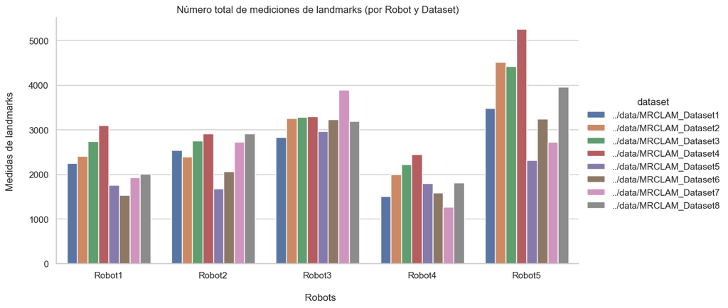

```python
# Representar número de medidas de landmarks (no de robots)
import seaborn as sns
import matplotlib.pyplot as plt

# Configurar el estilo de Seaborn
sns.set(style="whitegrid")

# Crear un gráfico de barras para la longitud promedio
g = sns.catplot(data=metrics, x='robot', y='n_landmarks', hue='dataset', kind='bar', aspect=2)

# Configurar el título y etiquetas de los ejes
plt.title("Número total de mediciones de landmarks (por Robot y Dataset)")
plt.xlabel("\n  Robots")
plt.ylabel("Medidas de landmarks\n")

# Mostrar el gráfico
plt.show()
```

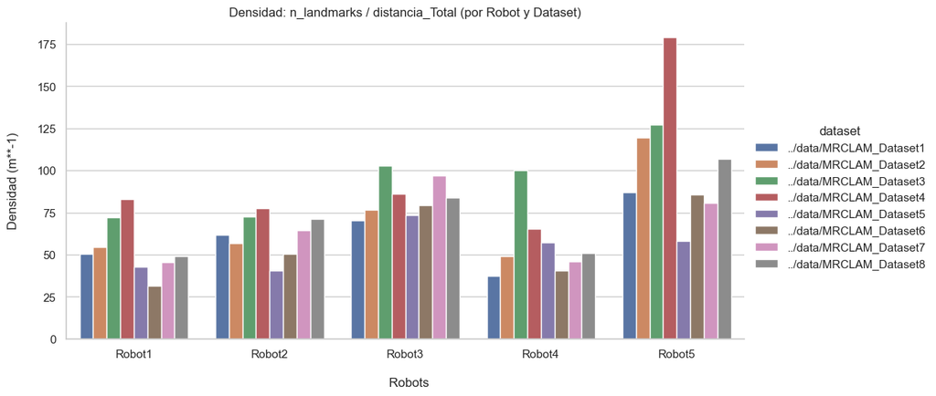

```python
# Representar la densidad #landmarks/groundtruth
import seaborn as sns
import matplotlib.pyplot as plt

# Configurar el estilo de Seaborn
sns.set(style="whitegrid")

# Crear un gráfico de barras para la longitud promedio
g = sns.catplot(data=metrics, x='robot', y='m_density', hue='dataset', kind='bar', aspect=2)

# Configurar el título y etiquetas de los ejes
plt.title("Densidad: n_landmarks / distancia_Total (por Robot y Dataset)")
plt.xlabel("\n  Robots")
plt.ylabel("Densidad (m**-1)\n")

# Mostrar el gráfico
plt.show()
```

# Analize the results and select three datasets with different 'distance','m_density' for the next lab sessions.

De los resultados obtenidos y lo que vemos en las gráficas podemos decir que:

```
- Robot1 en Dataset6 es donde se recorre más distancia.
- Robot5 en Dataset4 es el que más medidas de landmarks tiene y
respecto a la distancia recorrida el que más densidad tiene.
- Robot4 es el que menos medidas tiene tanto de distancia como de landmarks
sea cual sea su DataSet (en terminos generales).
```

Para las siguientes sesiones de laboratorios me quedaré con 3 Datasets representativos y apreciar esas diferencias:

```
- El Dataset4 por tener el Robot5 más densidad.
- El Dataset6 por tener el Robot1 menos densidad pero más distancia recorrida
por lo que quiere decir que es el menos medidas de landmarks (en proporción).
- El Dataset3 por tener una buena densidad media en todos los Robots.
```

```python
metrics.describe()
```

|  | length | duration | distance | m_density |
| --- | --- | --- | --- | --- |
| count | 40.000000 | 40.000000 | 40.000000 | 40.000000 |
| mean | 38.459248 | 714.984000 | 2.921862 | 72.084740 |
| std | 4.828625 | 46.405633 | 1.676229 | 28.560504 |
| min | 22.244821 | 649.496000 | 0.513213 | 31.505404 |
| 25% | 37.457919 | 677.743250 | 1.454655 | 50.646024 |
| 50% | 39.886894 | 709.633000 | 2.974144 | 70.717448 |
| 75% | 40.947688 | 735.022000 | 3.910006 | 84.152791 |
| max | 48.721800 | 883.038000 | 6.925408 | 178.776405 |